# Introduction to R programming - Mohit Sharma

R uses the fucntion to perform operation. To run a function called funcname, we type funcname(input1, input2), where the inputs tell R how to run the function.

For example to create a vector of numbers, we use the function c() for concatenate.

```r
x <- c(1,2,3,4,5)
x
```

1. 1

2. 2

3. 3

4. 4

5. 5

```r
class(x)
```

'numeric'

Any numbers inside the paratheses are joined together and save them as a vector named x. When we type x, it give us back the vector. We can save things using = rather than <-

```r
x = c(1,2,3,4,5)
x
```

1. 1

2. 2

3. 3

4. 4

5. 5

```r
class(x)
```

'numeric'

Typing ?funcname will always cause R to open a new help file window with additional information about the function

```r
?c
```

| c {base} | R Documentation |
| --- | --- |

Combine Values into a Vector or List

Description

This is a generic function which combines its arguments.

The default method combines its arguments to form a vector. All arguments are coerced to a common type which is the type of the returned value, and all attributes except names are removed.

Usage

```
## S3 Generic function
c(...)

## Default S3 method:
c(..., recursive = FALSE, use.names = TRUE)
```

Arguments

| `...` | objects to be concatenated. |
| --- | --- |
| `recursive` | logical. If `recursive = TRUE`, the function recursively descends through lists (and pairlists) combining all their elements into a vector. |
| `use.names` | logical indicating if `names` should be preserved. |

Details

The output type is determined from the highest type of the components in the hierarchy NULL < raw < logical < integer < double < complex < character < list < expression. Pairlists are treated as lists, whereas non-vector components (such names and calls) are treated as one-element lists which cannot be unlisted even if `recursive = TRUE`.

Note that `factor`s are treated only via their internal `integer` codes; one proposal has been to use

```
   c.factor <- function(..., recursive=TRUE) unlist(list(...), recursive=recursive)
```

if factor concatenation by `c()` should give a `factor`.

`c` is sometimes used for its side effect of removing attributes except names, for example to turn an array into a vector. `as.vector` is a more intuitive way to do this, but also drops names. Note that methods other than the default are not required to do this (and they will almost certainly preserve a class attribute).

This is a primitive function.

Value

`NULL` or an expression or a vector of an appropriate mode. (With no arguments the value is `NULL`.)

S4 methods

This function is S4 generic, but with argument list `(x, ...)`.

References

Becker, R. A., Chambers, J. M. and Wilks, A. R. (1988) *The New S Language*. Wadsworth & Brooks/Cole.

See Also

`unlist` and `as.vector` to produce attribute-free vectors.

Examples

```
c(1,7:9)
c(1:5, 10.5, "next")

## uses with a single argument to drop attributes
x <- 1:4
names(x) <- letters[1:4]
x
c(x)          # has names
as.vector(x)  # no names
dim(x) <- c(2,2)
x
c(x)
as.vector(x)

## append to a list:
ll <- list(A = 1, c = "C")
## do *not* use
c(ll, d = 1:3) # which is == c(ll, as.list(c(d = 1:3)))
## but rather
c(ll, d = list(1:3))  # c() combining two lists

c(list(A = c(B = 1)), recursive = TRUE)

c(options(), recursive = TRUE)
c(list(A = c(B = 1, C = 2), B = c(E = 7)), recursive = TRUE)
```

[Package *base* version 3.6.1 ]

We can tell R to add two sets of numbers together. It will then add the first number from x to the first number from y, and so on. However, x ad y should be the same length. We can check the lenght using length() function

```r
length(x)
```

5

```r
y =  c(1,2,3,4,5)
length(y)
```

5

ls() function allows us to look at a list of all of the objects, such as data and functions, that we have saved so far. The rm() function can be used to delete any that we don't want

```r
ls()
```

1. 'x'

2. 'y'

```r
rm(x)
```

```r
length(x)  # x is now deleted
```

```
Error in eval(expr, envir, enclos): object 'x' not found
Traceback:
```

It's also possible to delete all the objects at once.

```r
rm(list=ls())
```

```r
ls()
```

The matrix() function can be used to create a matrix of numbers. Before we use the matrix() function, we can learn more about it.

```r
?matrix()
```

| matrix {base} | R Documentation |
| --- | --- |

Matrices

Description

`matrix` creates a matrix from the given set of values.

`as.matrix` attempts to turn its argument into a matrix.

`is.matrix` tests if its argument is a (strict) matrix.

Usage

```
matrix(data = NA, nrow = 1, ncol = 1, byrow = FALSE,
       dimnames = NULL)

as.matrix(x, ...)
## S3 method for class 'data.frame'
as.matrix(x, rownames.force = NA, ...)

is.matrix(x)
```

Arguments

| `data` | an optional data vector (including a list or `expression` vector). Non-atomic classed **R** objects are coerced by `as.vector` and all attributes discarded. |
| --- | --- |
| `nrow` | the desired number of rows. |
| `ncol` | the desired number of columns. |
| `byrow` | logical. If `FALSE` (the default) the matrix is filled by columns, otherwise the matrix is filled by rows. |
| `dimnames` | A `dimnames` attribute for the matrix: `NULL` or a `list` of length 2 giving the row and column names respectively. An empty list is treated as `NULL`, and a list of length one as row names. The list … |
| `x` | an **R** object. |
| `...` | additional arguments to be passed to or from methods. |
| `rownames.force` | logical indicating if the resulting matrix should have character (rather than `NULL`) `rownames`. The default, `NA`, uses `NULL` rownames if the data frame has ‘automatic’ row.names or for a zero-row … |

Details

If one of `nrow` or `ncol` is not given, an attempt is made to infer it from the length of `data` and the other parameter. If neither is given, a one-column matrix is returned.

If there are too few elements in `data` to fill the matrix, then the elements in `data` are recycled. If `data` has length zero, `NA` of an appropriate type is used for atomic vectors (`0` for raw vectors) and `NULL` for lists.

`is.matrix` returns `TRUE` if `x` is a vector and has a `"dim"` attribute of length 2 and `FALSE` otherwise. Note that a `data.frame` is **not** a matrix by this test. The function is generic: you can write methods to handle specific classes of objects, see InternalMethods.

`as.matrix` is a generic function. The method for data frames will return a character matrix if there is only atomic columns and any non-(numeric/logical/complex) column, applying `as.vector` to factors and `format` to other non-character columns. Otherwise, the usual coercion hierarchy (logical < integer < double < complex) will be used, e.g., all-logical data frames will be coerced to a logical matrix, mixed logical-integer will give a integer matrix, etc.

The default method for `as.matrix` calls `as.vector(x)`, and hence e.g. coerces factors to character vectors.

When coercing a vector, it produces a one-column matrix, and promotes the names (if any) of the vector to the rownames of the matrix.

`is.matrix` is a primitive function.

The `print` method for a matrix gives a rectangular layout with dimnames or indices. For a list matrix, the entries of length not one are printed in the form integer,7 indicating the type and length.

Note

If you just want to convert a vector to a matrix, something like

```
  dim(x) <- c(nx, ny)
  dimnames(x) <- list(row_names, col_names)
```

will avoid duplicating `x`.

References

Becker, R. A., Chambers, J. M. and Wilks, A. R. (1988) *The New S Language*. Wadsworth & Brooks/Cole.

See Also

`data.matrix`, which attempts to convert to a numeric matrix.

A matrix is the special case of a two-dimensional `array`.

Examples

```
is.matrix(as.matrix(1:10))
!is.matrix(warpbreaks)  # data.frame, NOT matrix!
warpbreaks[1:10,]
as.matrix(warpbreaks[1:10,])  # using as.matrix.data.frame(.) method

## Example of setting row and column names
mdat <- matrix(c(1,2,3, 11,12,13), nrow = 2, ncol = 3, byrow = TRUE,
               dimnames = list(c("row1", "row2"),
                               c("C.1", "C.2", "C.3")))
mdat
```

[Package *base* version 3.6.1 ]

Let's create a very simple matrix!

```r
# Named of the matrix is mat
mat = matrix(data = c(1,2,3,4,5,6), nrow=3, ncol=2)
mat
```

| 1 | 4 |
| --- | --- |
| 2 | 5 |
| 3 | 6 |

`Note`- We could just as well omit typing data=,nrow=,ncol=,in the matrix() command baove that is, we could just type.

`mat = matrix(c(1,2,3,4,5,6),3,2)`

As the above examples illustrates, by default R creates matrices by successively filling in columns. Alternatively, the brow=`TRUE` option can be used to populate the matrix in order of the rows.

```r
mat = matrix(c(1,2,3,4),2,2,byrow = TRUE)
mat
```

| 1 | 2 |
| --- | --- |
| 3 | 4 |

`sqrt()` function returns the square root of each element of a vector or matrix. The command x^2 raises the element of x to the power of 2; any power 2; any powers are possible, including the fractional or negative powers.

```r
sqrt(2.10100)
```

1.44948266633306

```r
sqrt(16)
```

4

```r
sqrt(mat)
```

| 1.000000 | 1.414214 |
| --- | --- |
| 1.732051 | 2.000000 |

The `rnorm()` function generates a vector of random variable, we will first argument n the sample size. Each time we call this function, we will get a different answer. Here, we create two correlated sets of numbers, x and y, and use the cor() function to compute the correlation between them.

```r
?rnorm
```

| Normal {stats} | R Documentation |
| --- | --- |

The Normal Distribution

Description

Density, distribution function, quantile function and random generation for the normal distribution with mean equal to `mean` and standard deviation equal to `sd`.

Usage

```
dnorm(x, mean = 0, sd = 1, log = FALSE)
pnorm(q, mean = 0, sd = 1, lower.tail = TRUE, log.p = FALSE)
qnorm(p, mean = 0, sd = 1, lower.tail = TRUE, log.p = FALSE)
rnorm(n, mean = 0, sd = 1)
```

Arguments

| `x, q` | vector of quantiles. |
| --- | --- |
| `p` | vector of probabilities. |
| `n` | number of observations. If `length(n) > 1`, the length is taken to be the number required. |
| `mean` | vector of means. |
| `sd` | vector of standard deviations. |
| `log, log.p` | logical; if TRUE, probabilities p are given as log(p). |
| `lower.tail` | logical; if TRUE (default), probabilities are *P[X ≤ x]* otherwise, *P[X > x]*. |

Details

If `mean` or `sd` are not specified they assume the default values of `0` and `1`, respectively.

The normal distribution has density

*f(x) = 1/(√(2 π) σ) e^-((x - μ)^2/(2 σ^2))*

where *μ* is the mean of the distribution and *σ* the standard deviation.

Value

`dnorm` gives the density, `pnorm` gives the distribution function, `qnorm` gives the quantile function, and `rnorm` generates random deviates.

The length of the result is determined by `n` for `rnorm`, and is the maximum of the lengths of the numerical arguments for the other functions.

The numerical arguments other than `n` are recycled to the length of the result. Only the first elements of the logical arguments are used.

For `sd = 0` this gives the limit as `sd` decreases to 0, a point mass at `mu`. `sd < 0` is an error and returns `NaN`.

Source

For `pnorm`, based on

Cody, W. D. (1993) Algorithm 715: SPECFUN – A portable FORTRAN package of special function routines and test drivers. *ACM Transactions on Mathematical Software* **19**, 22–32.

For `qnorm`, the code is a C translation of

Wichura, M. J. (1988) Algorithm AS 241: The percentage points of the normal distribution. *Applied Statistics*, **37**, 477–484.

which provides precise results up to about 16 digits.

For `rnorm`, see RNG for how to select the algorithm and for references to the supplied methods.

References

Becker, R. A., Chambers, J. M. and Wilks, A. R. (1988) *The New S Language*. Wadsworth & Brooks/Cole.

Johnson, N. L., Kotz, S. and Balakrishnan, N. (1995) *Continuous Univariate Distributions*, volume 1, chapter 13. Wiley, New York.

See Also

Distributions for other standard distributions, including `dlnorm` for the *Log*normal distribution.

Examples

```
require(graphics)

dnorm(0) == 1/sqrt(2*pi)
dnorm(1) == exp(-1/2)/sqrt(2*pi)
dnorm(1) == 1/sqrt(2*pi*exp(1))

## Using "log = TRUE" for an extended range :
par(mfrow = c(2,1))
plot(function(x) dnorm(x, log = TRUE), -60, 50,
     main = "log { Normal density }")
curve(log(dnorm(x)), add = TRUE, col = "red", lwd = 2)
mtext("dnorm(x, log=TRUE)", adj = 0)
mtext("log(dnorm(x))", col = "red", adj = 1)

plot(function(x) pnorm(x, log.p = TRUE), -50, 10,
     main = "log { Normal Cumulative }")
curve(log(pnorm(x)), add = TRUE, col = "red", lwd = 2)
mtext("pnorm(x, log=TRUE)", adj = 0)
mtext("log(pnorm(x))", col = "red", adj = 1)

## if you want the so-called 'error function'
erf <- function(x) 2 * pnorm(x * sqrt(2)) - 1
## (see Abramowitz and Stegun 29.2.29)
## and the so-called 'complementary error function'
erfc <- function(x) 2 * pnorm(x * sqrt(2), lower = FALSE)
## and the inverses
erfinv <- function (x) qnorm((1 + x)/2)/sqrt(2)
erfcinv <- function (x) qnorm(x/2, lower = FALSE)/sqrt(2)
```

[Package *stats* version 3.6.1 ]

```r
x = rnorm(50)
x
```

1. -1.70420458860567

2. 0.412903782375071

3. -0.13266380312625

4. 0.981288964791208

5. 0.452765355914914

6. 0.253979517279344

7. -1.30315884928281

8. -0.713049915403186

9. -1.58279749137088

10. -1.57254227528577

11. 1.79843547590405

12. -0.456842894083955

13. -0.164931577970854

14. 0.0202191524625231

15. -0.337549649583724

16. 1.23000615856985

17. -1.15339973431986

18. -0.616564010095635

19. -1.26604000348052

20. 1.85922093371051

21. 1.84000251535733

22. 1.79803228294151

23. 1.175311877294

24. 0.885044377918776

25. -0.299311382054265

26. 0.178076551110665

27. -0.381115733119079

28. 1.02346232091408

29. 0.322179671519143

30. -0.970822362924072

31. 1.8628484931717

32. 0.403486266120688

33. 0.0654679751565612

34. -0.123402188277484

35. -0.578822661398158

36. 1.78512923555636

37. 0.490809097546129

38. -0.125034157655296

39. 1.14603050751525

40. 0.779255030092789

41. -0.898448202247564

42. -1.46050054764268

43. -0.534452516872436

44. -3.34835050504019

45. 0.197170711119102

46. 0.285908616857985

47. -0.527485941459135

48. 0.59440724300759

49. -0.894743343985388

50. 0.757605223718202

```r
y = x+rnorm(50, mean = 50, sd=.1)
y
```

1. 48.4088265394109

2. 50.3245118490257

3. 49.9091066397313

4. 51.1261684210558

5. 50.4369139672677

6. 50.1988053620423

7. 48.651178944548

8. 49.1040526978601

9. 48.5181356078457

10. 48.5030913592075

11. 51.8155099818186

12. 49.5475762502554

13. 49.8627017145198

14. 49.8511925356655

15. 49.7142289186454

16. 51.350568124092

17. 48.6749746511736

18. 49.5277897135881

19. 48.7286107436765

20. 51.969579309501

21. 52.0820428415861

22. 51.7125475548186

23. 51.1599618649053

24. 50.9543379820428

25. 49.6141429425523

26. 50.171854869254

27. 49.5997218215741

28. 50.9950518767282

29. 50.3391412536205

30. 48.9784043821273

31. 51.9160469643889

32. 50.3299441285349

33. 50.0720472932092

34. 49.7313498044896

35. 49.4461292181139

36. 51.8745332526508

37. 50.6221411086559

38. 50.0298159673959

39. 51.1847838033976

40. 50.8050302318664

41. 49.0138234850533

42. 48.3891816397239

43. 49.5468566396679

44. 46.9171268969298

45. 50.1158049540088

46. 50.4203638037444

47. 49.3770386085126

48. 50.6379511546634

49. 49.2826792690837

50. 50.731910479677

```r
cor(x,y)
```

0.995664185673938

By Default, rnorm() creates standard normal random variables with a mean of 0 and sd 1. However, the mean and sd can be altered by using the mean and sd arguments, as illustrated above. Sometimes, we want our code to reproduce the exact same set of random numbers, we can use the set.seed() function to do this. The set.seed() function takes an arbitrary integer argument.

```r
set.seed(1303)
rnorm(50)
```

1. -1.14397631447974

2. 1.34212936561501

3. 2.18539047574276

4. 0.536392517923731

5. 0.0631929664685468

6. 0.502234482468979

7. -0.000416724686432643

8. 0.565819840539162

9. -0.572522688962623

10. -1.11022500727696

11. -0.0486871233624514

12. -0.695656217619366

13. 0.828917480303335

14. 0.206652855081802

15. -0.235674509102427

16. -0.556310491381104

17. -0.364754357080585

18. 0.862355034263622

19. -0.63077153536771

20. 0.313602125215739

21. -0.931495317661393

22. 0.823867618473952

23. 0.523370702077482

24. 0.706921411979056

25. 0.420204325601679

26. -0.269052154682033

27. -1.51031729990999

28. -0.69021247657504

29. -0.143471952443572

30. -1.0135274099044

31. 1.57327373614751

32. 0.0127465054882014

33. 0.872647049887217

34. 0.422066190530336

35. -0.0188157916578866

36. 2.61574896890584

37. -0.693140174826871

38. -0.266321780991085

39. -0.720636441231524

40. 1.36773420645149

41. 0.264007332160512

42. 0.632186807367191

43. -1.33065098578719

44. 0.0268888182209596

45. 1.0406363207788

46. 1.31202379854711

47. -0.0300020766733214

48. -0.250025712488174

49. 0.0234144856913592

50. 1.65987065574227

We will going to use set.seed() throught out the labs. The mean() and var() functions can be used to compute the mean and variance of a vector of numbers. Applying the sqrt() to the output of var() will give the standard deviation (sd). or you can directly use the sd().

```r
set.seed(3)
y = rnorm(100)
mean(y)
```

0.0110355710943715

```r
var(y)
```

0.732867501277449

```r
sqrt(var(y))
```

0.856076808047881

```r
sd(y)
```

0.856076808047881

# Graphics

The plot() function is the primary way to plot the data in R. For instance, plot(x,y) produces a scatterplot of the numbers in x versus the numbers in y. There are many additional options that can be passed in to the plot() function. For example, passing in the argument xlab will result in a label on the x-axis. To find out more information about the plot() function type ?plot()

```r
?plot()
```

| plot {graphics} | R Documentation |
| --- | --- |

Generic X-Y Plotting

Description

Generic function for plotting of **R** objects. For more details about the graphical parameter arguments, see `par`.

For simple scatter plots, `plot.default` will be used. However, there are `plot` methods for many **R** objects, including `function`s, `data.frame`s, `density` objects, etc. Use `methods(plot)` and the documentation for these.

Usage

```
plot(x, y, ...)
```

Arguments

`x`

the coordinates of points in the plot. Alternatively, a single plotting structure, function or *any **R** object with a `plot` method* can be provided.

`y`

the y coordinates of points in the plot, *optional* if `x` is an appropriate structure.

`...`

Arguments to be passed to methods, such as graphical parameters (see `par`). Many methods will accept the following arguments:

**`type`**

what type of plot should be drawn. Possible types are

- `"p"` for **p**oints,

- `"l"` for **l**ines,

- `"b"` for **b**oth,

- `"c"` for the lines part alone of `"b"`,

- `"o"` for both ‘**o**verplotted’,

- `"h"` for ‘**h**istogram’ like (or ‘high-density’) vertical lines,

- `"s"` for stair **s**teps,

- `"S"` for other **s**teps, see ‘Details’ below,

- `"n"` for no plotting.

All other `type`s give a warning or an error; using, e.g., `type = "punkte"` being equivalent to `type = "p"` for S compatibility. Note that some methods, e.g. `plot.factor`, do not accept this.

**`main`**

an overall title for the plot: see `title`.

**`sub`**

a sub title for the plot: see `title`.

**`xlab`**

a title for the x axis: see `title`.

**`ylab`**

a title for the y axis: see `title`.

**`asp`**

the *y/x* aspect ratio, see `plot.window`.

Details

The two step types differ in their x-y preference: Going from *(x1,y1)* to *(x2,y2)* with *x1 < x2*, `type = "s"` moves first horizontal, then vertical, whereas `type = "S"` moves the other way around.

See Also

`plot.default`, `plot.formula` and other methods; `points`, `lines`, `par`. For thousands of points, consider using `smoothScatter()` instead of `plot()`.

For X-Y-Z plotting see `contour`, `persp` and `image`.

Examples

```
require(stats) # for lowess, rpois, rnorm
plot(cars)
lines(lowess(cars))

plot(sin, -pi, 2*pi) # see ?plot.function

## Discrete Distribution Plot:
plot(table(rpois(100, 5)), type = "h", col = "red", lwd = 10,
     main = "rpois(100, lambda = 5)")

## Simple quantiles/ECDF, see ecdf() {library(stats)} for a better one:
plot(x <- sort(rnorm(47)), type = "s", main = "plot(x, type = \"s\")")
points(x, cex = .5, col = "dark red")
```

[Package *graphics* version 3.6.1 ]

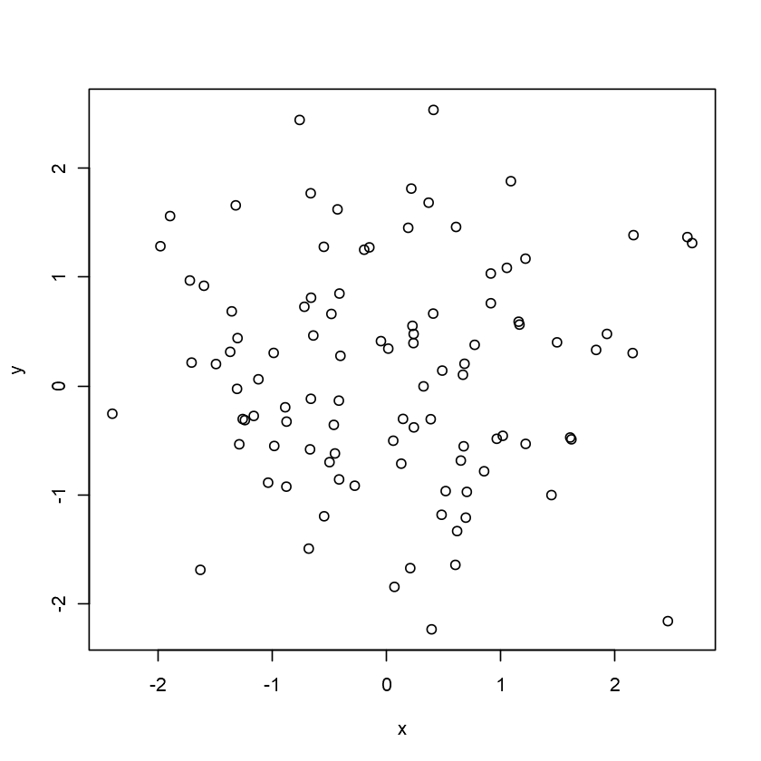

```r
x = rnorm(100)
y = rnorm(100)
plot(x,y)
```

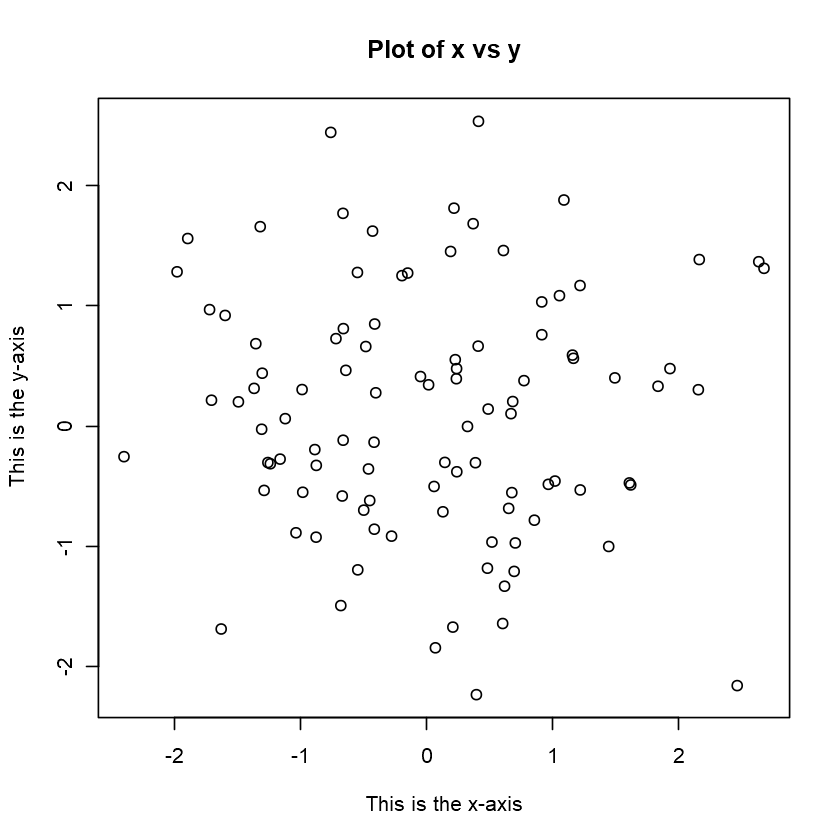

```r
plot(x,y,xlab="This is the x-axis", ylab= "This is the y-axis", main="Plot of x vs y")
```

Sometimes, we want to save our output of an R plot. The Command that we use to do this will depend on the file type that we would like to create. For instance, we create a pdf, using the pdf() function, and to create jpeg(), we use the jpeg() function.

```r
pdf("Figure.pdf")
```

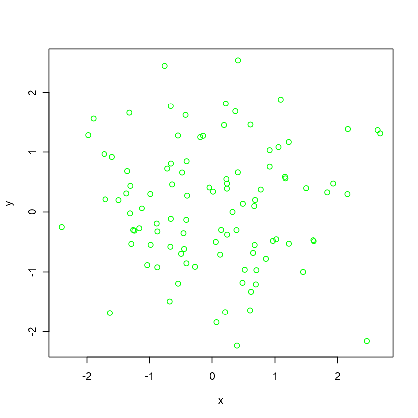

```r
plot(x,y,col = "green")
```

```r
dev.off()
```

**pdf:** 3

The function dev.off() indicates to R we are done creating the plot. Alternatively, we can simply copy the plot window and paste it into the an appropriate file type, such a Word document.

```r
?dev.off
```

| dev {grDevices} | R Documentation |
| --- | --- |

Control Multiple Devices

Description

These functions provide control over multiple graphics devices.

Usage

```
dev.cur()
dev.list()
dev.next(which = dev.cur())
dev.prev(which = dev.cur())
dev.off(which = dev.cur())
dev.set(which = dev.next())
dev.new(..., noRStudioGD = FALSE)
graphics.off()
```

Arguments

| `which` | An integer specifying a device number. |
| --- | --- |
| `...` | arguments to be passed to the device selected. |
| `noRStudioGD` | Do not use the RStudio graphics device even if specified as the default device: it does not accept arguments such as `width` and `height`. |

Details

Only one device is the ‘active’ device: this is the device in which all graphics operations occur. There is a `"null device"` which is always open but is really a placeholder: any attempt to use it will open a new device specified by `getOption("device")`.

Devices are associated with a name (e.g., `"X11"` or `"postscript"`) and a number in the range 1 to 63; the `"null device"` is always device 1. Once a device has been opened the null device is not considered as a possible active device. There is a list of open devices, and this is considered as a circular list not including the null device. `dev.next` and `dev.prev` select the next open device in the appropriate direction, unless no device is open.

`dev.off` shuts down the specified (by default the current) device. If the current device is shut down and any other devices are open, the next open device is made current. It is an error to attempt to shut down device 1. `graphics.off()` shuts down all open graphics devices. Normal termination of a session runs the internal equivalent of `graphics.off()`.

`dev.set` makes the specified device the active device. If there is no device with that number, it is equivalent to `dev.next`. If `which = 1` it opens a new device and selects that.

`dev.new` opens a new device. Normally **R** will open a new device automatically when needed, but this enables you to open further devices in a platform-independent way. (For which device is used see `getOption("device")`.) Note that care is needed with file-based devices such as `pdf` and `postscript` and in that case file names such as ‘Rplots.pdf’, ‘Rplots1.pdf’, ..., ‘Rplots999.pdf’ are tried in turn. Only named arguments are passed to the device, and then only if they match the argument list of the device. Even so, care is needed with the interpretation of e.g. `width`, and for the standard bitmap devices `units = "in", res = 72` is forced if neither is supplied but both `width` and `height` are.

Value

`dev.cur` returns a length-one named integer vector giving the number and name of the active device, or 1, the null device, if none is active.

`dev.list` returns the numbers of all open devices, except device 1, the null device. This is a numeric vector with a `names` attribute giving the device names, or `NULL` is there is no open device.

`dev.next` and `dev.prev` return the number and name of the next / previous device in the list of devices. This will be the null device if and only if there are no open devices.

`dev.off` returns the number and name of the new active device (after the specified device has been shut down).

`dev.set` returns the number and name of the new active device.

`dev.new` returns the return value of the device opened, usually invisible `NULL`.

See Also

`Devices`, such as `postscript`, etc.

`layout` and its links for setting up plotting regions on the current device.

Examples

```
## Not run: ## Unix-specific example
x11()
plot(1:10)
x11()
plot(rnorm(10))
dev.set(dev.prev())
abline(0, 1) # through the 1:10 points
dev.set(dev.next())
abline(h = 0, col = "gray") # for the residual plot
dev.set(dev.prev())
dev.off(); dev.off() #- close the two X devices

## End(Not run)
```

[Package *grDevices* version 3.6.1 ]

The function seq() can be used to create a sequence of numbers. For instance, seq(a,b) makes a vector of integers between a and b. There are many other options: for instance seq(0,1,length=10) makes a sequence of 10 numbers that are equally spaced between 0 and 1. Typing 3:11 is a shorthand for seq(3,11) for integer arguments.

```r
x = seq(1,10)
x
```

1. 1

2. 2

3. 3

4. 4

5. 5

6. 6

7. 7

8. 8

9. 9

10. 10

```r
x = 1:10
x
```

1. 1

2. 2

3. 3

4. 4

5. 5

6. 6

7. 7

8. 8

9. 9

10. 10

```r
x = seq(-pi,pi,length=50)
x
```

1. -3.14159265358979

2. -3.0133643820147

3. -2.88513611043961

4. -2.75690783886451

5. -2.62867956728942

6. -2.50045129571433

7. -2.37222302413923

8. -2.24399475256414

9. -2.11576648098904

10. -1.98753820941395

11. -1.85930993783886

12. -1.73108166626376

13. -1.60285339468867

14. -1.47462512311358

15. -1.34639685153848

16. -1.21816857996339

17. -1.0899403083883

18. -0.961712036813202

19. -0.833483765238109

20. -0.705255493663015

21. -0.577027222087922

22. -0.448798950512828

23. -0.320570678937734

24. -0.192342407362641

25. -0.064114135787547

26. 0.0641141357875465

27. 0.19234240736264

28. 0.320570678937734

29. 0.448798950512828

30. 0.577027222087921

31. 0.705255493663015

32. 0.833483765238108

33. 0.961712036813202

34. 1.0899403083883

35. 1.21816857996339

36. 1.34639685153848

37. 1.47462512311358

38. 1.60285339468867

39. 1.73108166626376

40. 1.85930993783886

41. 1.98753820941395

42. 2.11576648098904

43. 2.24399475256414

44. 2.37222302413923

45. 2.50045129571433

46. 2.62867956728942

47. 2.75690783886451

48. 2.88513611043961

49. 3.0133643820147

50. 3.14159265358979

Let's create some more sophisticated plots. The contour() function produces a contour plot() in order to represent three dimensional data; it is like a topographical map.

It takes three arguments:

1. A vector of the x values (first dimension)
2. A vector of the y values (the second dimension), and
3. A matrix whose elements correspond to the z-value ( the third dimension) for each pari of (x,y) coordinates.

As with the plot() function there are many other inputs that can be used to fine-tune the output of the contour() function.

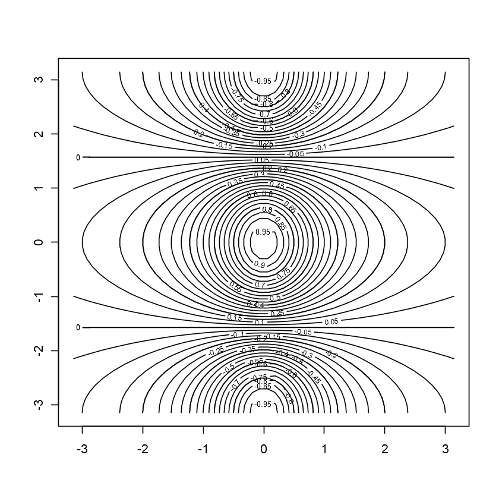

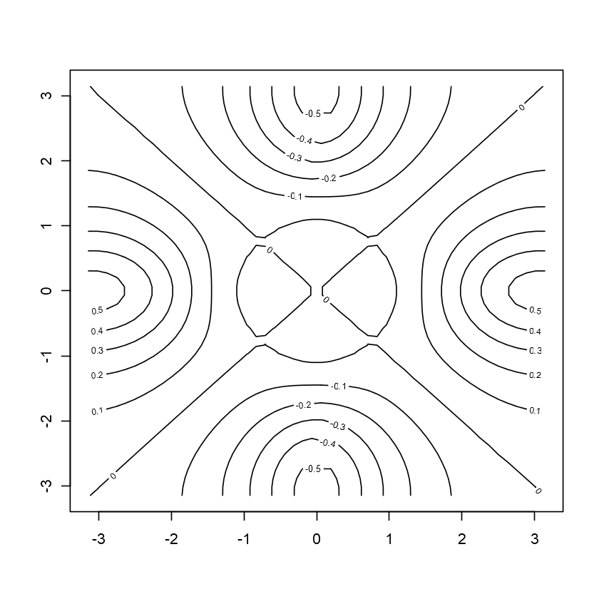

```r
y=x
f = outer(x,y,function(x,y)cos(y)/(1+x^2))
contour(x,y,f)
contour(x,y,f,nlevels=45,add=T)
fa = (f-t(f))/2
contour(x,y,fa,nlevels=15)
```

The image() function works the same way as contour(), except that it produces the color-coded plot whose colors depend on the z value. This is know as `heatmap`. and is sometimes used to plot temperature in weather forecasts. Alternativerly, persp() can be used to produce a three dimensional plot. The arguments theta and phi control the angles at which the plot is viewed.

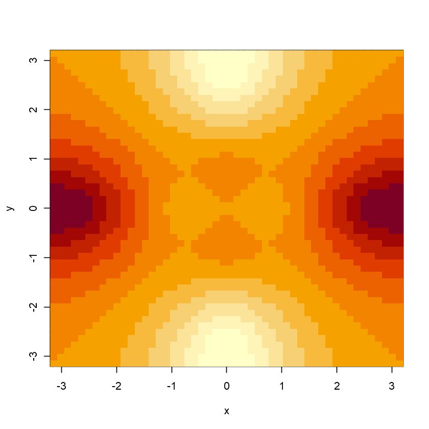

```r
image(x,y,fa)
```

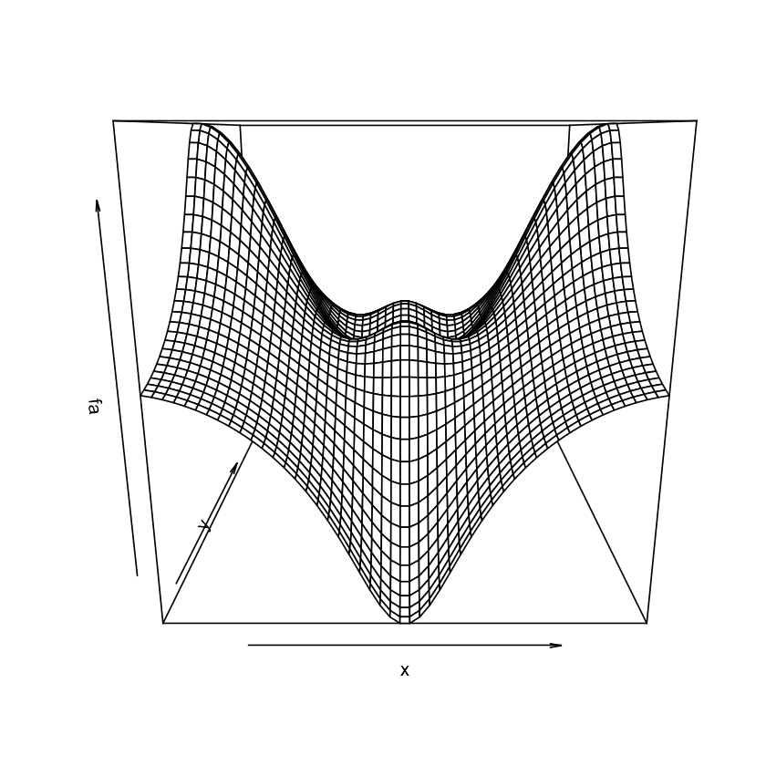

```r
persp(x,y,fa)
```

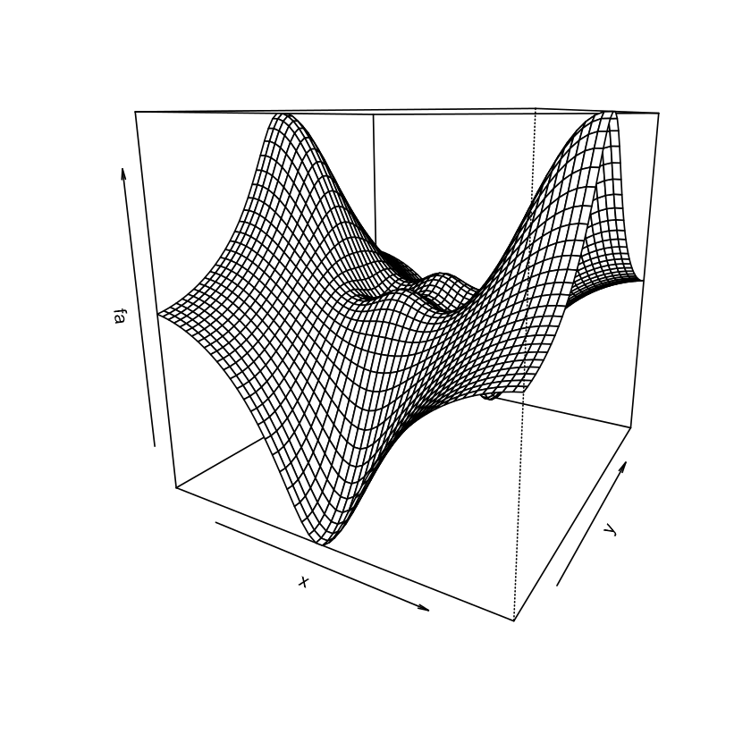

```r
persp(x,y,fa,theta = 30)
```

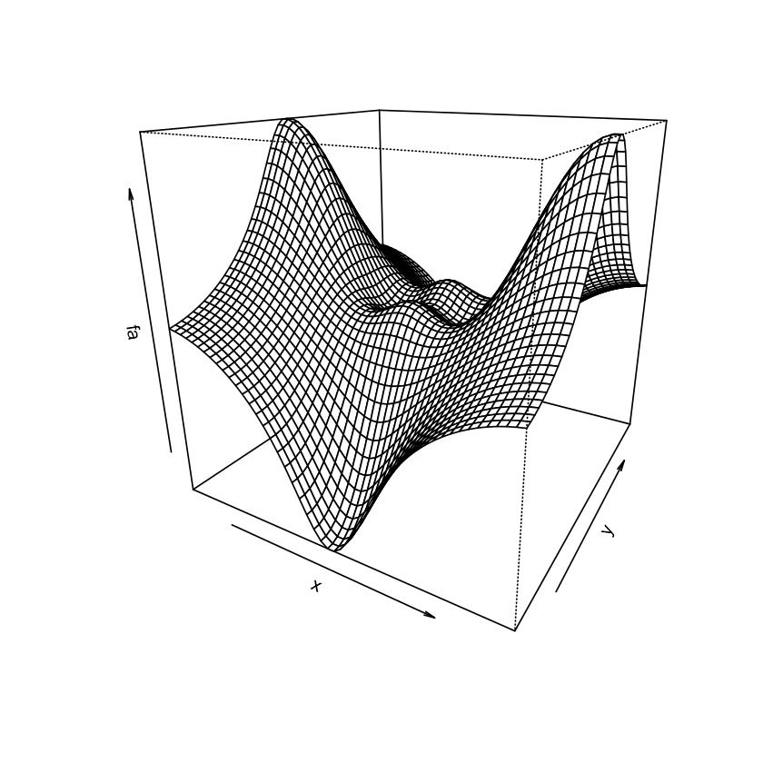

```r
persp(x,y,fa, theta = 30, phi=20)
```

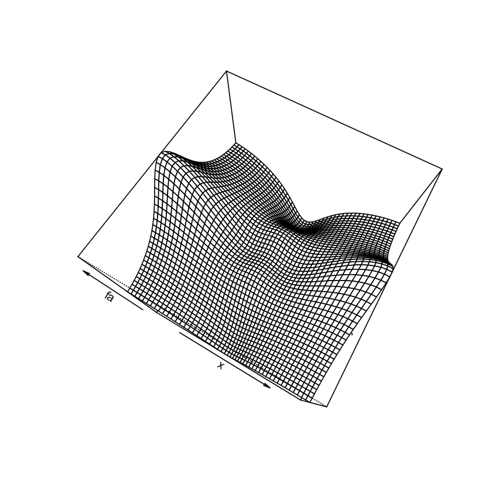

```r
persp(x,y,fa, theta = 30, phi=70)
```

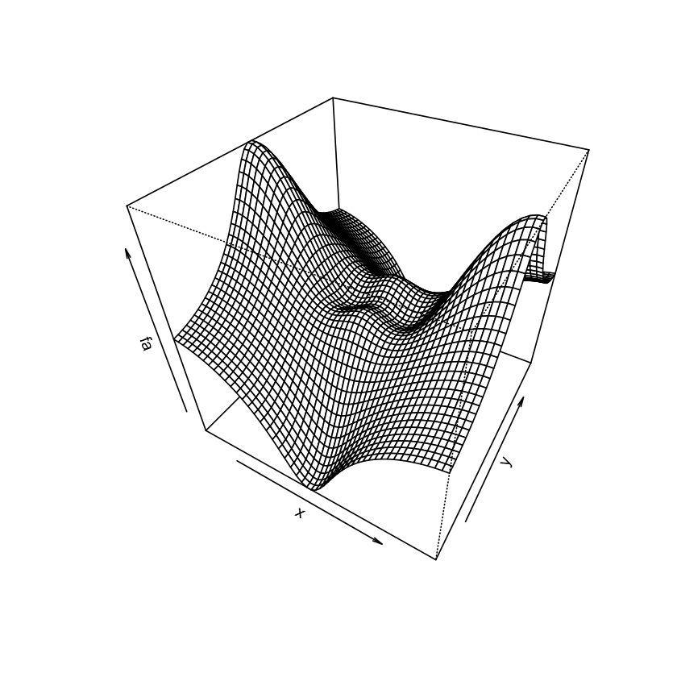

```r
persp(x,y,fa,theta = 30, phi=40)
```

# Indexing Data

We often wish to examine the part of a set of data. Suppose that our data is stored in the matrix A

```r
A = matrix(1:16, 4,4)
A
```

| 1 | 5 | 9 | 13 |
| --- | --- | --- | --- |
| 2 | 6 | 10 | 14 |
| 3 | 7 | 11 | 15 |
| 4 | 8 | 12 | 16 |

```r
A[2,3]
```

10

Above, will select the element corresponding to the second row and the third column. The first number after the open brack symbol `[` always refers to the row, and the second number refers to column. We can select multiple rows and columns at a time, by providing vectors as the indics.

```r
A[2:4]
```

1. 2

2. 3

3. 4

```r
A[2:4,2:4]
```

| 6 | 10 | 14 |
| --- | --- | --- |
| 7 | 11 | 15 |
| 8 | 12 | 16 |

```r
A[c(1,3),c(2,4)]
```

| 5 | 13 |
| --- | --- |
| 7 | 15 |

```r
A[1:3,2:4]
```

| 5 | 9 | 13 |
| --- | --- | --- |
| 6 | 10 | 14 |
| 7 | 11 | 15 |

```r
A[1:2,]
```

| 1 | 5 | 9 | 13 |
| --- | --- | --- | --- |
| 2 | 6 | 10 | 14 |

```r
A[,1:2]
```

| 1 | 5 |
| --- | --- |
| 2 | 6 |
| 3 | 7 |
| 4 | 8 |

The last two examples include either no index for the columns or no index for the rows. These indicates that R should include all the columns or all the rows, respectively. R treats a single row or columns of a matrix as a vector.

```r
A[1,]
```

1. 1

2. 5

3. 9

4. 13

The use of `-ve` sign in the index tells R to keep all the rows or columns except those indicated in the index.

```r
A[-c(1,3),]
```

| 2 | 6 | 10 | 14 |
| --- | --- | --- | --- |
| 4 | 8 | 12 | 16 |

Lastly, dim() function outputs the number of rows followed by the number of columns of a given matrix.

```r
dim(A)
```

1. 4

2. 4

# Loading Data

For most analyses, the first step involves importing the dataset into R. The `read.table()` function is the one of the primary ways to do this.The help file contains details about how to use this function. We can use the function, `write.table()` to export data.

Before attempting, to load a dataset, we must make sure that R knows to search for the data in the proper directory. For example on a windows system one could select the directory using the `change dir`... option under the File menu.However, the details of how to do this depend on the operating system(e.g. Windows, Mac, Linux etc.)that is being used.

ISLR package contains all the dataset which I will be using in the labs.

```r
# uncomment the below line and download the package
# install.packages("ISLR")
```

```r
library("ISLR")
```

```r
Auto
```

|  | mpg | cylinders | displacement | horsepower | weight | acceleration | year | origin | name |
| --- | --- | --- | --- | --- | --- | --- | --- | --- | --- |
| 1 | 18 | 8 | 307 | 130 | 3504 | 12.0 | 70 | 1 | chevrolet chevelle malibu |
| 2 | 15 | 8 | 350 | 165 | 3693 | 11.5 | 70 | 1 | buick skylark 320 |
| 3 | 18 | 8 | 318 | 150 | 3436 | 11.0 | 70 | 1 | plymouth satellite |
| 4 | 16 | 8 | 304 | 150 | 3433 | 12.0 | 70 | 1 | amc rebel sst |
| 5 | 17 | 8 | 302 | 140 | 3449 | 10.5 | 70 | 1 | ford torino |
| 6 | 15 | 8 | 429 | 198 | 4341 | 10.0 | 70 | 1 | ford galaxie 500 |
| 7 | 14 | 8 | 454 | 220 | 4354 | 9.0 | 70 | 1 | chevrolet impala |
| 8 | 14 | 8 | 440 | 215 | 4312 | 8.5 | 70 | 1 | plymouth fury iii |
| 9 | 14 | 8 | 455 | 225 | 4425 | 10.0 | 70 | 1 | pontiac catalina |
| 10 | 15 | 8 | 390 | 190 | 3850 | 8.5 | 70 | 1 | amc ambassador dpl |
| 11 | 15 | 8 | 383 | 170 | 3563 | 10.0 | 70 | 1 | dodge challenger se |
| 12 | 14 | 8 | 340 | 160 | 3609 | 8.0 | 70 | 1 | plymouth 'cuda 340 |
| 13 | 15 | 8 | 400 | 150 | 3761 | 9.5 | 70 | 1 | chevrolet monte carlo |
| 14 | 14 | 8 | 455 | 225 | 3086 | 10.0 | 70 | 1 | buick estate wagon (sw) |
| 15 | 24 | 4 | 113 | 95 | 2372 | 15.0 | 70 | 3 | toyota corona mark ii |
| 16 | 22 | 6 | 198 | 95 | 2833 | 15.5 | 70 | 1 | plymouth duster |
| 17 | 18 | 6 | 199 | 97 | 2774 | 15.5 | 70 | 1 | amc hornet |
| 18 | 21 | 6 | 200 | 85 | 2587 | 16.0 | 70 | 1 | ford maverick |
| 19 | 27 | 4 | 97 | 88 | 2130 | 14.5 | 70 | 3 | datsun pl510 |
| 20 | 26 | 4 | 97 | 46 | 1835 | 20.5 | 70 | 2 | volkswagen 1131 deluxe sedan |
| 21 | 25 | 4 | 110 | 87 | 2672 | 17.5 | 70 | 2 | peugeot 504 |
| 22 | 24 | 4 | 107 | 90 | 2430 | 14.5 | 70 | 2 | audi 100 ls |
| 23 | 25 | 4 | 104 | 95 | 2375 | 17.5 | 70 | 2 | saab 99e |
| 24 | 26 | 4 | 121 | 113 | 2234 | 12.5 | 70 | 2 | bmw 2002 |
| 25 | 21 | 6 | 199 | 90 | 2648 | 15.0 | 70 | 1 | amc gremlin |
| 26 | 10 | 8 | 360 | 215 | 4615 | 14.0 | 70 | 1 | ford f250 |
| 27 | 10 | 8 | 307 | 200 | 4376 | 15.0 | 70 | 1 | chevy c20 |
| 28 | 11 | 8 | 318 | 210 | 4382 | 13.5 | 70 | 1 | dodge d200 |
| 29 | 9 | 8 | 304 | 193 | 4732 | 18.5 | 70 | 1 | hi 1200d |
| 30 | 27 | 4 | 97 | 88 | 2130 | 14.5 | 71 | 3 | datsun pl510 |
| ... | ... | ... | ... | ... | ... | ... | ... | ... | ... |
| 368 | 28 | 4 | 112 | 88 | 2605 | 19.6 | 82 | 1 | chevrolet cavalier |
| 369 | 27 | 4 | 112 | 88 | 2640 | 18.6 | 82 | 1 | chevrolet cavalier wagon |
| 370 | 34 | 4 | 112 | 88 | 2395 | 18.0 | 82 | 1 | chevrolet cavalier 2-door |
| 371 | 31 | 4 | 112 | 85 | 2575 | 16.2 | 82 | 1 | pontiac j2000 se hatchback |
| 372 | 29 | 4 | 135 | 84 | 2525 | 16.0 | 82 | 1 | dodge aries se |
| 373 | 27 | 4 | 151 | 90 | 2735 | 18.0 | 82 | 1 | pontiac phoenix |
| 374 | 24 | 4 | 140 | 92 | 2865 | 16.4 | 82 | 1 | ford fairmont futura |
| 375 | 36 | 4 | 105 | 74 | 1980 | 15.3 | 82 | 2 | volkswagen rabbit l |
| 376 | 37 | 4 | 91 | 68 | 2025 | 18.2 | 82 | 3 | mazda glc custom l |
| 377 | 31 | 4 | 91 | 68 | 1970 | 17.6 | 82 | 3 | mazda glc custom |
| 378 | 38 | 4 | 105 | 63 | 2125 | 14.7 | 82 | 1 | plymouth horizon miser |
| 379 | 36 | 4 | 98 | 70 | 2125 | 17.3 | 82 | 1 | mercury lynx l |
| 380 | 36 | 4 | 120 | 88 | 2160 | 14.5 | 82 | 3 | nissan stanza xe |
| 381 | 36 | 4 | 107 | 75 | 2205 | 14.5 | 82 | 3 | honda accord |
| 382 | 34 | 4 | 108 | 70 | 2245 | 16.9 | 82 | 3 | toyota corolla |
| 383 | 38 | 4 | 91 | 67 | 1965 | 15.0 | 82 | 3 | honda civic |
| 384 | 32 | 4 | 91 | 67 | 1965 | 15.7 | 82 | 3 | honda civic (auto) |
| 385 | 38 | 4 | 91 | 67 | 1995 | 16.2 | 82 | 3 | datsun 310 gx |
| 386 | 25 | 6 | 181 | 110 | 2945 | 16.4 | 82 | 1 | buick century limited |
| 387 | 38 | 6 | 262 | 85 | 3015 | 17.0 | 82 | 1 | oldsmobile cutlass ciera (diesel) |
| 388 | 26 | 4 | 156 | 92 | 2585 | 14.5 | 82 | 1 | chrysler lebaron medallion |
| 389 | 22 | 6 | 232 | 112 | 2835 | 14.7 | 82 | 1 | ford granada l |
| 390 | 32 | 4 | 144 | 96 | 2665 | 13.9 | 82 | 3 | toyota celica gt |
| 391 | 36 | 4 | 135 | 84 | 2370 | 13.0 | 82 | 1 | dodge charger 2.2 |
| 392 | 27 | 4 | 151 | 90 | 2950 | 17.3 | 82 | 1 | chevrolet camaro |
| 393 | 27 | 4 | 140 | 86 | 2790 | 15.6 | 82 | 1 | ford mustang gl |
| 394 | 44 | 4 | 97 | 52 | 2130 | 24.6 | 82 | 2 | vw pickup |
| 395 | 32 | 4 | 135 | 84 | 2295 | 11.6 | 82 | 1 | dodge rampage |
| 396 | 28 | 4 | 120 | 79 | 2625 | 18.6 | 82 | 1 | ford ranger |
| 397 | 31 | 4 | 119 | 82 | 2720 | 19.4 | 82 | 1 | chevy s-10 |

```r
fix(Auto)
```

Once the data has been loaded, the fix() function can be used to view, it in a spreadsheet like windows. However, the window must be closed before further R Commands can be entered.

Sometimes dataset has not been loaded correctly, because R has assumed the variable names are part of the data and so has included them in the first row. In that cases, put header=T

```r
dim(Auto)   # if you notice here it's showing 392 rather than 397 because R by defualt omit the na rows.
```

1. 392

2. 9

# Additional Graphical and Numerical Summaries

We can use plot() function to produce scatterplot of the quantitative varaibles. However, simply typing the variable names will produce an error message, because R does not know to look in the Auto dataset for those variables.

```r
plot(cylinders, mpg)
```

```
Error in plot(cylinders, mpg): object 'cylinders' not found
Traceback:

1. plot(cylinders, mpg)
```

To refer to a variable we must type the datset and the variable name joined with $ symbol. Alternatively, we can use attach() function in the order to tell R to make the variables in this dataframe available by name.

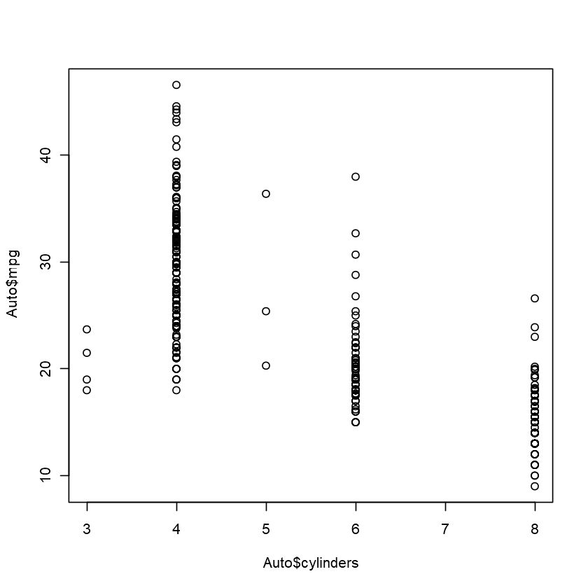

```r
plot(Auto$cylinders,Auto$mpg)
```

```r
attach(Auto)
```

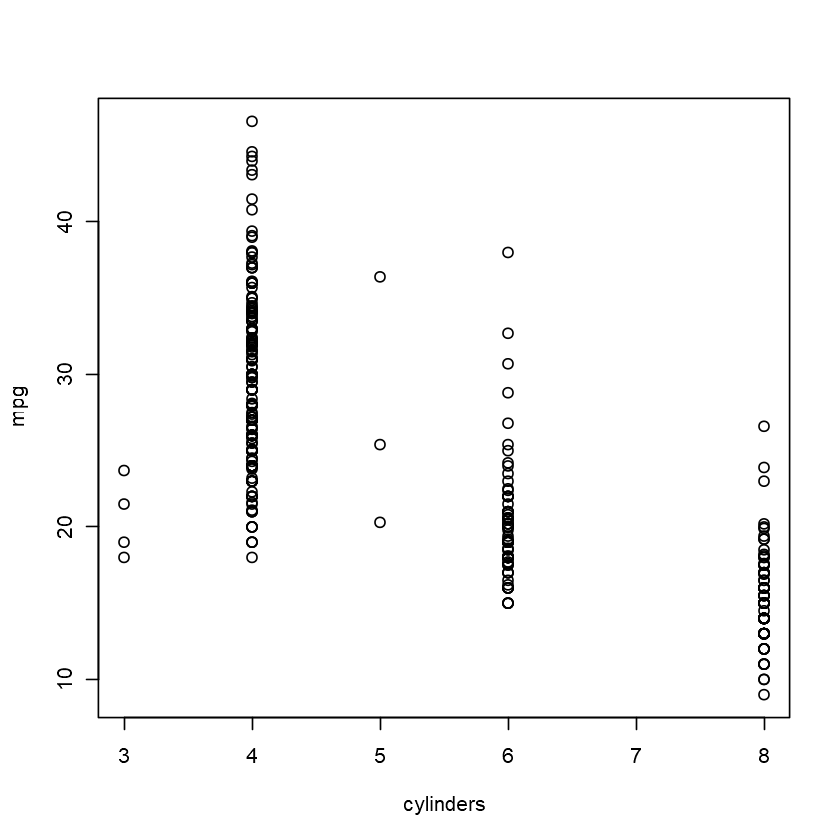

```r
plot(cylinders, mpg)
```

The cylinders variable is stored as a numeric vector, so R has treated it as quantitative. However, there are only a small number of possible values for cylinders, one may prefer to treat it as qualitative variable. The `as.factor()` function converts quantitative variable to qualitative variables.

```r
class(Auto$cylinders)
```

'numeric'

```r
cylinders <- as.factor(cylinders)
class(cylinders)
```

'factor'

If the variable plotted on x-axis is categorical then boxplots will automatically be produced by the plot() function

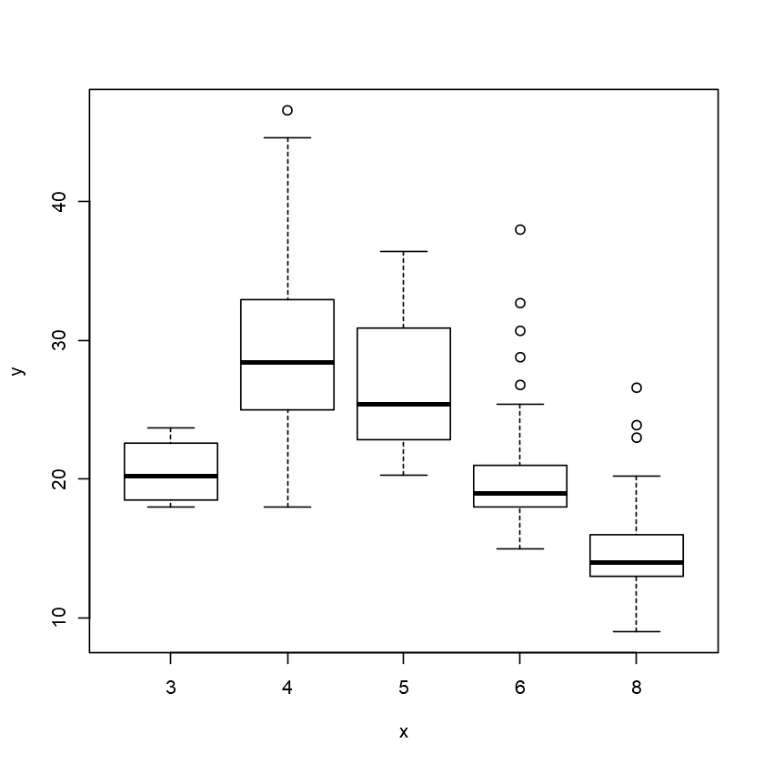

```r
plot(cylinders,mpg)
```

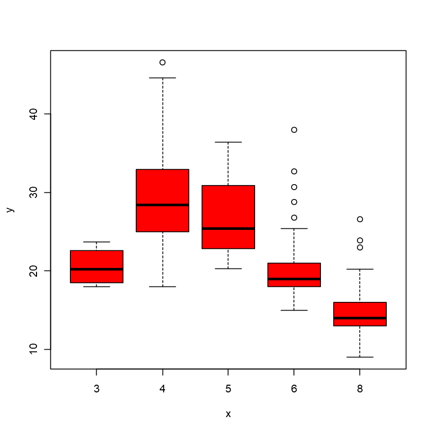

```r
plot(cylinders,mpg,col = "red")
```

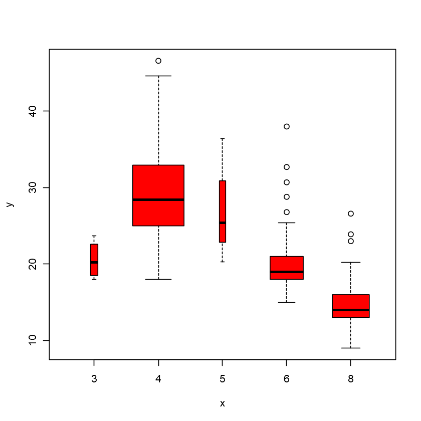

```r
plot(cylinders,mpg,col = "red", varwidth = T)
```

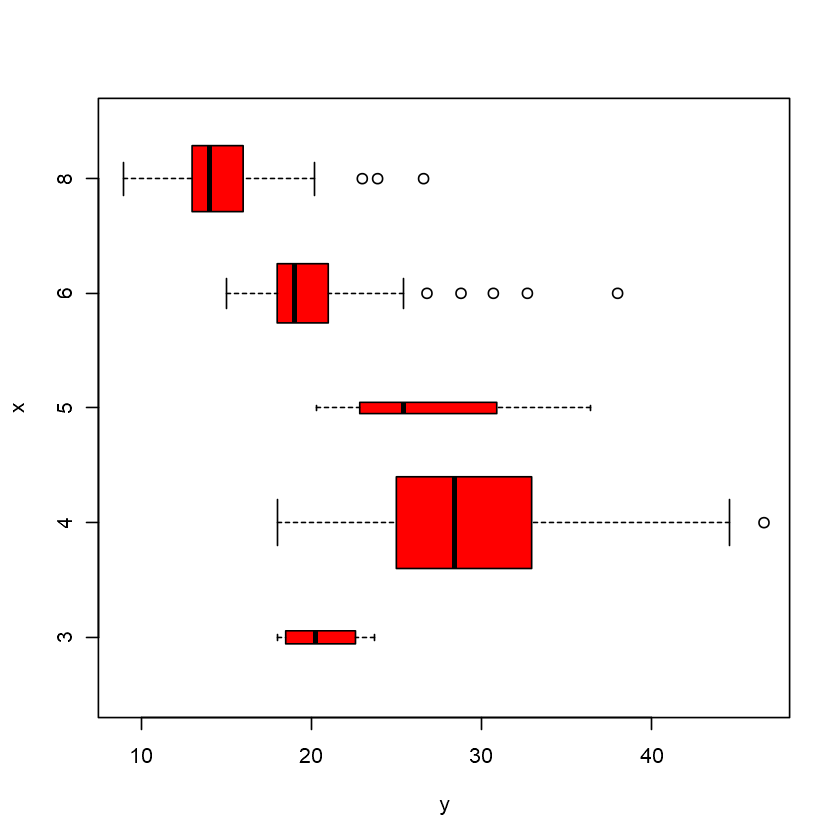

```r
plot(cylinders,mpg,col = "red", varwidth = T, horizontal = T)
```

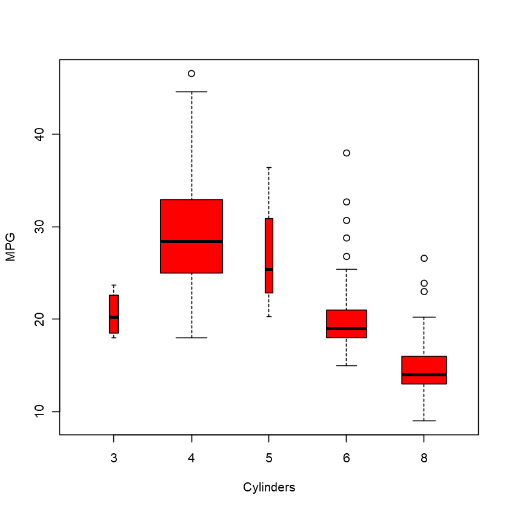

```r
plot(cylinders,mpg,col = "red", varwidth = T, xlab= "Cylinders", ylab ="MPG")
```

The `hist()` function can be used to plot histogram. Note col=2 has the same effect as col="red"

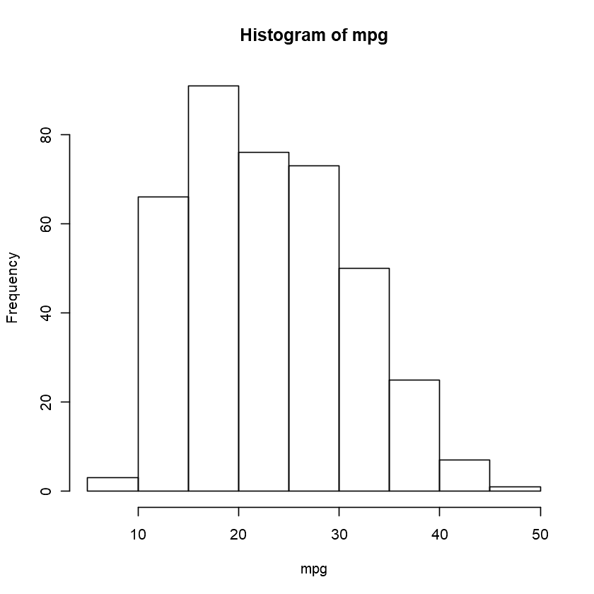

```r
hist(mpg)
```

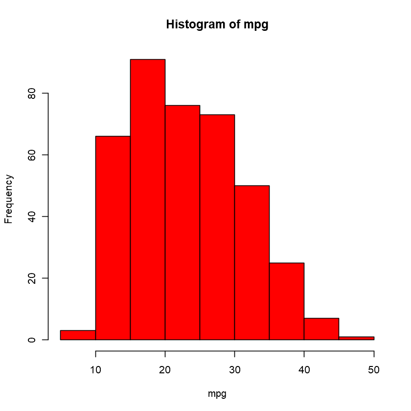

```r
hist(mpg,col=2)
```

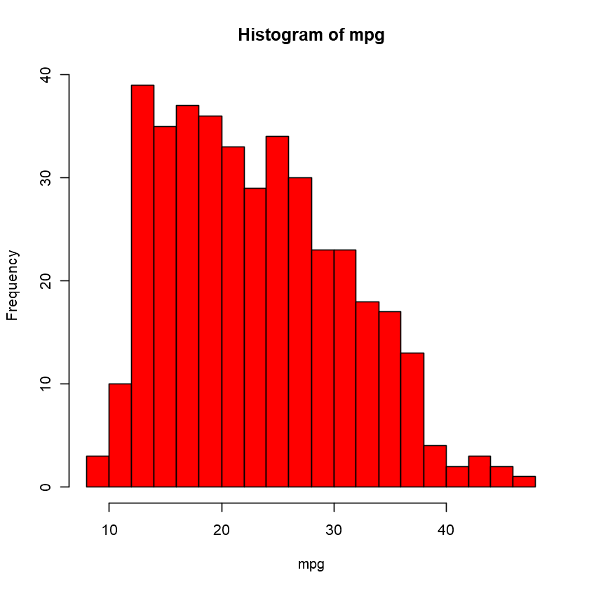

```r
hist(mpg,col=2,breaks = 15)
```

The `pairs()` function creates a scatterplot matrix i.e scatterplot for every pair of variables for any given dataset. We can also produce scatterplots for just a subset of the variables.

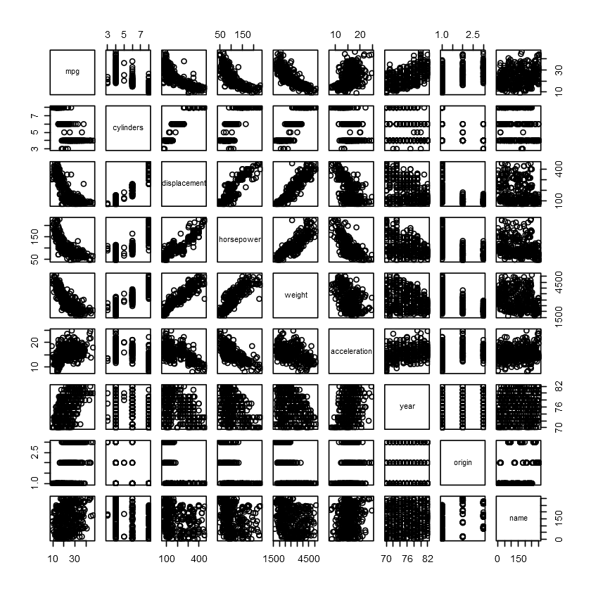

```r
pairs(Auto)
```

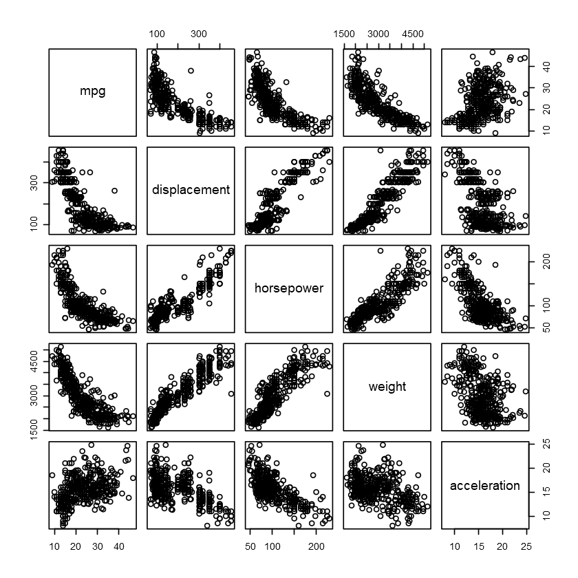

```r
pairs(~mpg + displacement+horsepower+weight+acceleration, Auto)
```

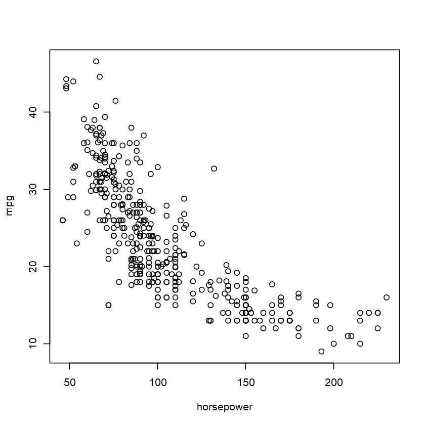

```r
plot(horsepower , mpg)
```

In conjunction with `plot()` function, `identify()` provides a useful interactive method for identifying the value for a particular variable for points on a plot.

```r
# plot(horsepower,mpg)
# identify(horsepower,mpg,name) # works in Rstudio
```

The summary() function provides a numerical summary of each variable in a particular dataset.

```r
summary(Auto)
```

```
      mpg          cylinders      displacement     horsepower        weight
 Min.   : 9.00   Min.   :3.000   Min.   : 68.0   Min.   : 46.0   Min.   :1613
 1st Qu.:17.00   1st Qu.:4.000   1st Qu.:105.0   1st Qu.: 75.0   1st Qu.:2225
 Median :22.75   Median :4.000   Median :151.0   Median : 93.5   Median :2804
 Mean   :23.45   Mean   :5.472   Mean   :194.4   Mean   :104.5   Mean   :2978
 3rd Qu.:29.00   3rd Qu.:8.000   3rd Qu.:275.8   3rd Qu.:126.0   3rd Qu.:3615
 Max.   :46.60   Max.   :8.000   Max.   :455.0   Max.   :230.0   Max.   :5140

  acceleration        year           origin                      name
 Min.   : 8.00   Min.   :70.00   Min.   :1.000   amc matador       :  5
 1st Qu.:13.78   1st Qu.:73.00   1st Qu.:1.000   ford pinto        :  5
 Median :15.50   Median :76.00   Median :1.000   toyota corolla    :  5
 Mean   :15.54   Mean   :75.98   Mean   :1.577   amc gremlin       :  4
 3rd Qu.:17.02   3rd Qu.:79.00   3rd Qu.:2.000   amc hornet        :  4
 Max.   :24.80   Max.   :82.00   Max.   :3.000   chevrolet chevette:  4
                                                 (Other)           :365
```

For qualitative variables such as name, R will list the number of observations that fall in each category.

```r
summary(mpg)
```

```
   Min. 1st Qu.  Median    Mean 3rd Qu.    Max.
   9.00   17.00   22.75   23.45   29.00   46.60
```

That's it for this tutorial. Come week, I am bringing more content to learn R basics.